# 1. Objective

The snRNA seq object loaded on Day 1 (191,795 nuclei) already carries quality control metrics computed by the original authors (Kuppe et al. 2022), along with a mitochondrial percentage, a doublet score, a dissociation stress score, and per nucleus count and gene totals. The total nucleus count in the downloaded object matches the number reported in the original publication, indicating the authors’ own filtering has already been applied upstream.

The purpose of this notebook is to inspect these metrics directly rather than assume their meaning, apply one additional, explicitly documented filtering step for reproducibility, and isolate the fibroblast population that this project focuses on.

# 2. Load Data

```r
library(Seurat)
library(tidyverse)

seurat_obj <- readRDS("data/processed/kuppe_seurat_raw.rds")
dim(seurat_obj)
```

```
## [1]  28380 191795
```

# 3. Inspecting Quality Control Metrics

```r
summary(seurat_obj@meta.data$percent_mito)
```

```
##    Min. 1st Qu.  Median    Mean 3rd Qu.    Max.
## 0.00000 0.02440 0.07806 0.16991 0.19493 4.99500
```

```r
summary(seurat_obj@meta.data$doublet_score)
```

```
##      Min.   1st Qu.    Median      Mean   3rd Qu.      Max.
## 9.660e-06 9.583e-04 6.041e-03 3.355e-02 2.599e-02 9.209e-01
```

```r
summary(seurat_obj@meta.data$dissociation_score)
```

```
##     Min.  1st Qu.   Median     Mean  3rd Qu.     Max.
## -0.13824  0.01661  0.05273  0.05963  0.09498  0.42043
```

```r
summary(seurat_obj@meta.data$n_counts)
```

```
##    Min. 1st Qu.  Median    Mean 3rd Qu.    Max.
##     501    1521    2561    5199    6541   53935
```

```r
summary(seurat_obj@meta.data$n_genes)
```

```
##    Min. 1st Qu.  Median    Mean 3rd Qu.    Max.
##     306    1073    1589    2021    2681    7376
```

The percent_mito maximum sits at 4.995, and the n_counts and n_genes minimums sit close to round numbers (501 and 306 respectively). This is expected for single nucleus data, where mitochondrial RNA content is naturally very low compared to whole cell data.

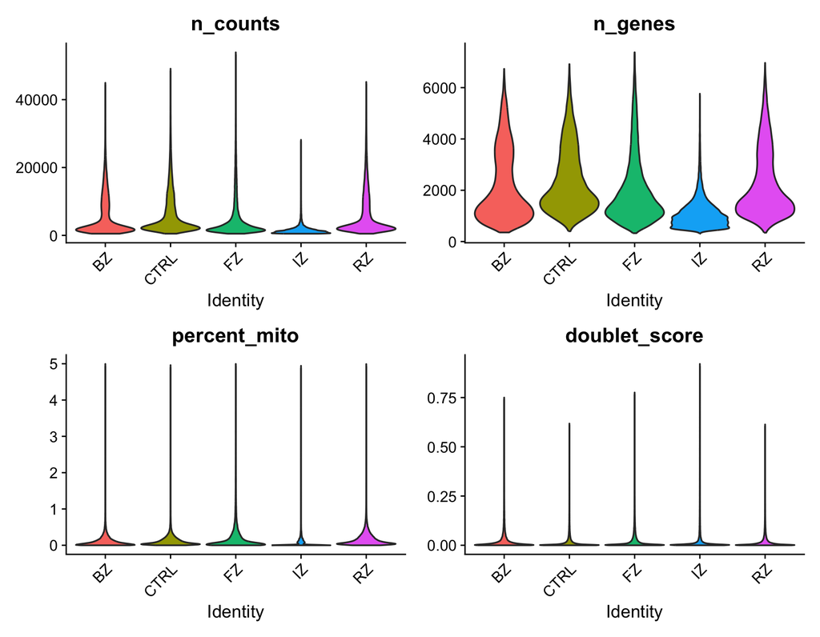

```r
VlnPlot(
  seurat_obj,
  features = c("n_counts", "n_genes", "percent_mito", "doublet_score"),
  group.by = "major_labl",
  pt.size = 0,
  ncol = 2
)
```

The ischemic zone (IZ) shows visibly lower n_counts and n_genes distributions relative to the other four zones. This is consistent with the expected biology of actively injured tissue rather than a technical artifact, and is preserved rather than filtered out. percent_mito and doublet_score distributions are broadly comparable across all five zones.

```r
FeatureScatter(
  seurat_obj,
  feature1 = "n_counts",
  feature2 = "percent_mito",
  group.by = "major_labl"
)
```

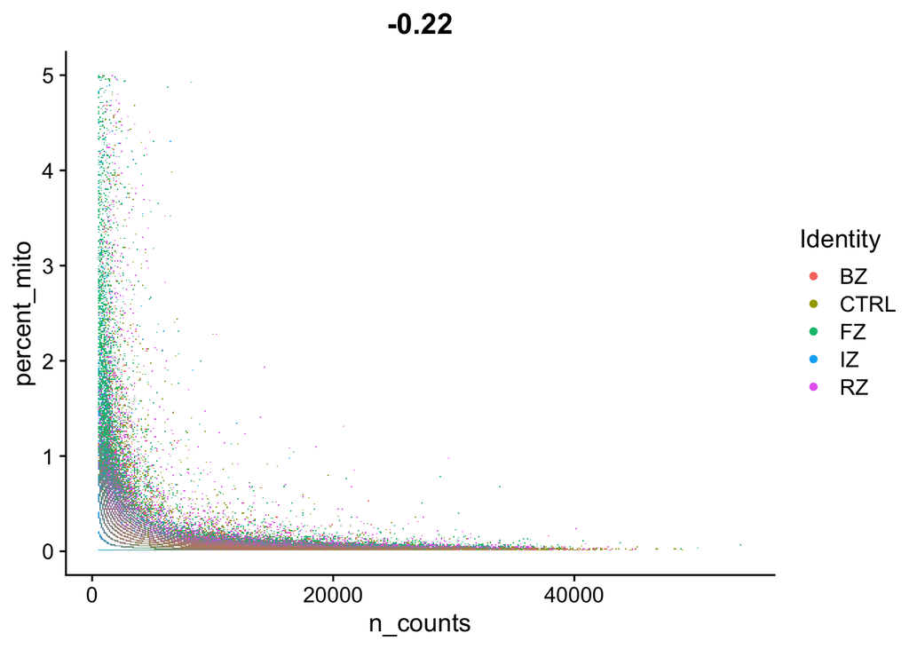

The relationship between total counts and mitochondrial percentage shows a single continuous distribution rather than two separated populations, which is expected signature of a distinct low quality subpopulation. This further supports that the dataset was already reasonably filtered before deposit.

# 4. Doublet Filtering Decision

Unlike percent_mito, n_counts, and n_genes, the doublet_score distribution does not show an obvious pre applied ceiling. Since the exact doublet filtering threshold used in the original publication could not be confirmed, an explicit threshold is applied here for reproducibility rather than relying on an unverified upstream setting.

```r
sum(seurat_obj@meta.data$doublet_score > 0.2)
```

```
## [1] 7811
```

```r
sum(seurat_obj@meta.data$doublet_score > 0.3)
```

```
## [1] 4276
```

```r
sum(seurat_obj@meta.data$doublet_score > 0.5)
```

```
## [1] 1178
```

```r
nrow(seurat_obj@meta.data)
```

```
## [1] 191795
```

At a threshold of 0.3, 4,276 nuclei (approximately 2.2 percent of the total) exceed the cutoff. This threshold was selected as a moderate, documented choice for reproducibility, while avoiding an aggressive cutoff that risks discarding larger, transcriptionally active fibroblast or myofibroblast nuclei that are biologically relevant to this project.

```r
seurat_obj <- subset(
  seurat_obj,
  subset = doublet_score < 0.3
)

nrow(seurat_obj@meta.data)
```

```
## [1] 187519
```

187,519 nuclei remain after this filtering step.

# 5. Subsetting to Fibroblasts

This project focuses specifically on the cardiac fibroblast lineage, as the research question concerns the transcriptional divergence between transient, reparative fibroblast senescence and persistent, pathological fibroblast senescence following myocardial infarction. Other cell types, including cardiomyocytes, endothelial cells, and vascular smooth muscle cells, are not the direct subject of this analysis, though they may be revisited later if cell to cell communication analysis is added.

```r
fibroblasts <- subset(
  seurat_obj,
  subset = cell_type_original == "Fibroblast"
)

dim(fibroblasts)
```

```
## [1] 28380 46453
```

```r
table(fibroblasts@meta.data$major_labl)
```

```
##
##    BZ  CTRL    FZ    IZ    RZ
##  6299  9346  9707  9970 11131
```

The fibroblast subset contains 46,453 nuclei across all five zones:

| Zone | Nuclei |
| --- | --- |
| BZ (border zone) | 6,299 |
| CTRL (control) | 9,346 |
| FZ (fibrotic zone) | 9,707 |
| IZ (ischemic zone) | 9,970 |
| RZ (remote zone) | 11,131 |

# 6. Save Output

```r
saveRDS(fibroblasts, "data/processed/kuppe_fibroblasts_qc.rds")
```

This file, containing 46,453 quality controlled fibroblast nuclei with metadata intact, is the starting point for Day 3 clustering and senescence scoring.